# R Reference

## 2.5 Manipulating data using `dplyr`

All of the main verbs in `dplyr` share the same syntax: `verb(data, arguments, ...)`.

Grouping performs all operations within each group, and `ungroup()`, well, ungroups.

```r
# filter()
filter(flights, month == 1, day == 1, dep_delay < 10) # can add as many as desired
flights %>% filter(month == 1, day == 1, dep_delay < 10) # equivalent, using pipe operator

# arrange()
flights %>% arrange(year, month, day) # ascending order
flights %>% arrange(desc(dep_delay)) # descending order: surround a variable with desc()

# select()
flights %>% select(year, month, day) # selects only those columns
flights %>% select(year:day) # all columns between year and day
flights %>% select(-day) # all columns except
flights %>% select(starts_with("abc"), ends_with("abc"), contains("rst"))
flights %>% select(delay = dep_delay) # rename variables (but keeps only that variable)
flights %>% rename(delay = dep_delay) # rename only that variable, keeping everything else
flights %>% select(year, month, day, everything()) # move a few variables to the front, keep all else

# mutate()
flights %>% mutate(gain = dep_delay - arr_delay) # adds new columns
flights %>% transmute(gain = dep_delay - arr_delay) # keeps only the new columns

# summarize() and group_by()
flights %>%
  group_by(origin, month) %>%
  summarize(n = n(),
            avgDelay = mean(dep_delay, na.rm = TRUE))
```

### 2.5.1 Helper functions for `mutate()`

- `+`, `-`, `*`, `/`, `^`, `%/%` (integer division), `%%` (remainder)
- `lead()` and `lag()` offsets a vector by 1
  - Calculate running differences: `x - lag(x)`
  - Find when values change between adjacent indices: `x != lag(x)`
- Cumulative and rolling aggregates: `cumsum()`, `cumprod()`, `cummin()`, `cummax()`, `cummean()`
  - For rolling aggregates, see the `RcppRoll` package
- `min_rank()` assigns ranks as we would expect, properly handling ties
  - Otherwise, see `row_number()`, `dense_rank()`, `percent_rank()`, `cume_dist()`, `ntile()`

### 2.5.2 Helper functions for `summary()`

- `mean()`, `median()`, `sd()`, `IQR()`, `mad()` (median absolute deviation, which is more robust)
- `quantile(x, 0.25)` for finding a quantile
- `n()`, `n_distinct()`, `sum(!is.na(x))`

## 2.6 Handling strings with `stringr`

### 2.6.1 Regular expressions

- `^` or `$` in a regex indicates that the pattern must occur at the beginning or end of the string
- `[]` indicates that we’re searching for anything within the brackets
- `\\s` indicates space character (`\s` is a space, and another `\` escapes it)
- `.` is any character
- `*` is any number of times

## 2.7 Handling dates and times with `lubridate`

## 2.8 Web scraping with `rvest`

# 3 Visualization

## 3.1 Base-R plots

The basic function is the `plot()` function:

```r
plot(trees$latitude, trees$longitude) # explicit vectors
plot(Exports ~ Imports, data = wb) # formula notation
plot(Exports ~ Imports, data = wb,
     lwd = 2,
     col = "red",
     xlab = "Imports",
     ylab = "Exports")
```

Mosaic plots using Base-R (note that the function does the aggregation automatically):

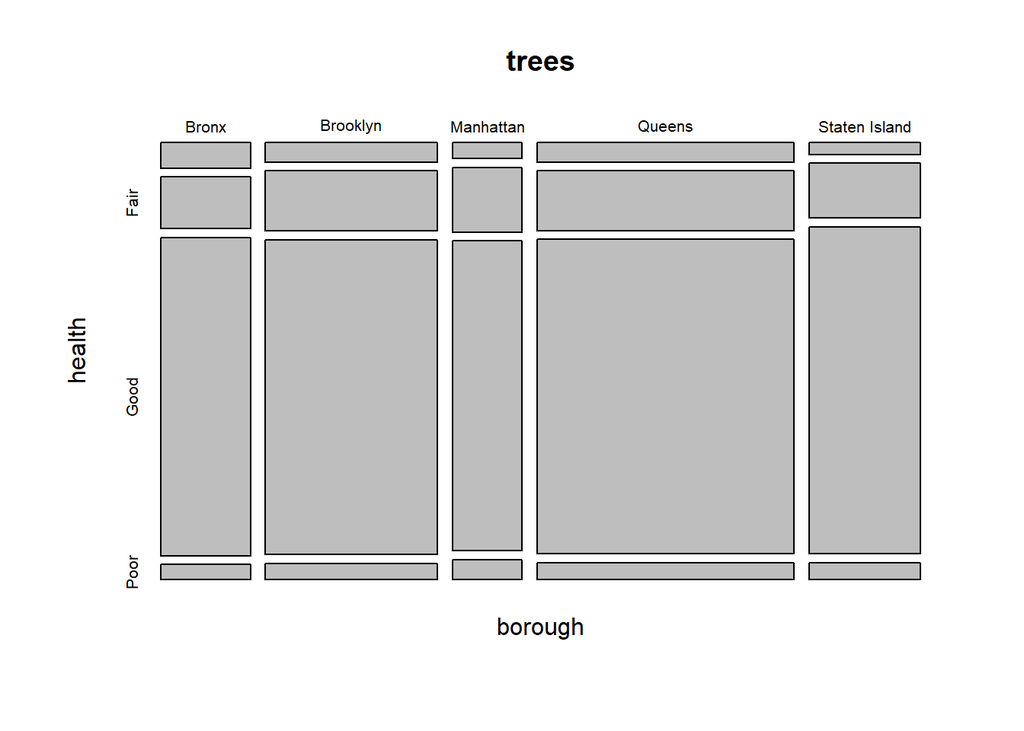

```r
mosaicplot(borough ~ health, data = trees)
```